# Multi-unidimensional Example

This example demonstrates how a multi-unidimensional IRT test can be presented in blocks of items at a time. This generally makes presentation more smooth, however you still will get the general benifits of using a MIRT model as opposed to seperate unidimensional models (especially after one block has been completed).

```r
library('mirtCAT')
options(stringsAsFactors = FALSE)

# define population IRT parameters
set.seed(1234)
nitems <- 100
itemnames <- paste0("Item.", 1:nitems)
a <- matrix(c(rlnorm(nitems/2, 0.2, 0.3), numeric(nitems), rlnorm(nitems/2, 0.2, 0.3)), nitems)

head(a) #first 6
```

```
##           [,1] [,2]
## [1,] 0.8503394    0
## [2,] 1.3274088    0
## [3,] 1.6910208    0
## [4,] 0.6042850    0
## [5,] 1.3892130    0
## [6,] 1.4216480    0
```

```r
tail(a) #last 6
```

```
##        [,1]      [,2]
## [95,]     0 1.0526649
## [96,]     0 1.3588858
## [97,]     0 0.8690258
## [98,]     0 1.5895661
## [99,]     0 1.6353797
## [100,]    0 2.3078933
```

```r
a[48:53, ] #middle
```

```
##           [,1]      [,2]
## [1,] 0.8389571 0.0000000
## [2,] 1.0437829 0.0000000
## [3,] 1.0522650 0.0000000
## [4,] 0.0000000 0.7104836
## [5,] 0.0000000 1.0257020
## [6,] 0.0000000 0.8757568
```

```r
d <- matrix(rnorm(nitems))
pars <- data.frame(a, d)
colnames(pars) <- c("a1", "a2", "d")
trait_cov <- matrix(c(1, 0.5, 0.5, 1), 2, 2)

# create mirt_object
mod <- generate.mirt_object(pars, itemtype = "2PL", latent_covariance = trait_cov)

# math items definitions addition for one factor and multiplication for the other
questions <- answers <- character(nitems)
options <- matrix("", nitems, 5)
spacing <- floor(d - min(d)) + 1  #easier items have more variation

for (i in 1:nitems) {
    if (i < 50) {
        # addition
        n1 <- sample(1:100, 1)
        n2 <- sample(101:200, 1)
        ans <- n1 + n2
        questions[i] <- paste0(n1, " + ", n2, " = ?")
    } else {
        # multiplication
        m1 <- sample(1:50, 1)
        m2 <- sample(1:50, 1)
        ans <- n1 + n2 + m1 * m2
        questions[i] <- paste0(m1, " * ", m2, " = ?")
    }
    answers[i] <- as.character(ans)
    ch <- ans + sample(c(-5:-1, 1:5) * spacing[i, ], 5)
    ch[sample(1:5, 1)] <- ans
    options[i, ] <- as.character(ch)
}

# load list of items and their answers
df <- data.frame(Question = questions, Option = options, Answer = answers, Type = "radio")

set.seed(1)
pat <- generate_pattern(mo = mod, Theta = c(-1, 1), df = df)
head(pat)
```

```
## [1] "207" "208" "221" "214" "244" "283"
```

The idea for setting up a multi-unidimesional item selection mechanism is to use the `customNextItem()` input so that the `subset` arguemnt to `findNextItem()` can be manipulated. Here we define two blocks to select from: a block from items 1:50, and 51:100. This means that when the first block is used only items 1:50 can be selected as the next item. Furthermore, we can do some manual checks to decide when the second block should begin. Here items will be selected until 20 items appear in each block.

```r
# standad MCAT
# res <- mirtCAT(df = df, mo = mod, criteria = "Drule", local_pattern = pat)

# custom. Often useful to set up a browser first for easier editing
customNextItem <- function(design, person, test){
    browser()

}

#res <- mirtCAT(df = df, mo = mod, local_pattern = pat,
#               design = list(customNextItem=customNextItem))

customNextItem <- function(design, person, test){
    block1 <- 1:50
    block2 <- 51:100
    total_answered <- sum(!is.na(extract.mirtCAT(person, 'items_answered')))
    if(total_answered < 20){ #first 20 items block1
        block <- block1
    } else if(total_answered < 40){ #next 20 block2
        block <- block2
    } else return(NA) # terminate when both item blocks have 20 items answered
    ret <- findNextItem(person=person, design=design, test=test,
                        subset=block, criteria = 'Arule')
    ret
}

res <- mirtCAT(df = df, mo = mod, local_pattern = pat,
               design = list(customNextItem=customNextItem,
                             min_SEM = 0)) #disable other termination criteria
```

Notice that the order of the results is correct, and that measurement of the second latent trait really only begins after the 20th item has been administered.

```r
print(res$items_answered[1:20])
```

```
##  [1]  1 20 31 24  3 15 14 16 39  6 41 34 49 50 21 32  9 23 19 25
```

```r
print(res$items_answered[21:40])
```

```
##  [1]  75  62  93 100  59  57  69  98  68  61  74  99  66  91  76  63  88
## [18]  73  94  79
```

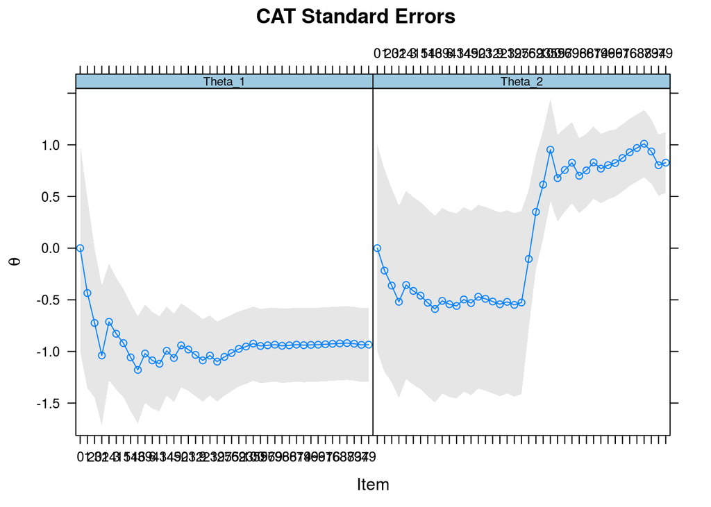

```r
plot(res)
```

To run the actual GUI, simply remove the `local_pattern` argument to let `mirtCAT()` know that the responses must be collected in real-time.

```r
res <- mirtCAT(df = df, mo = mod,
               design = list(customNextItem=customNextItem,
                             min_SEM = 0)) #disable other termination criteria
```